# How different are papaya ringspot virus strains around the world? A coat-protein gene analysis

R. Y. N. Wijesinghe

# 1 Aim

*Papaya ringspot virus* (PRSV) is one of the most damaging diseases of papaya. Virus-resistant papaya was developed in Hawaii using the **coat protein (CP) gene** of a Hawaiian PRSV strain, and this kind of resistance works best against strains with a similar CP sequence. This notebook uses public CP sequences from GenBank to ask:

1. Do PRSV strains from the **same world region** have more similar CP genes than strains from different regions?
2. How similar are strains from each region to the **Hawaiian strain** used to make resistant papaya?

Workflow: **download → cleaning → exploratory analysis → alignment → distances and statistical tests → phylogenetic tree → interpretation**.

# 2 Setup

```r
# dplyr is loaded LAST so its functions are not masked by Bioconductor ones.
suppressPackageStartupMessages({
  library(rentrez)     # download sequences from NCBI GenBank
  library(Biostrings)  # DNA sequence objects, GC content
  library(DECIPHER)    # multiple sequence alignment
  library(ape)         # genetic distances, neighbour-joining tree, bootstrap
  library(phangorn)    # midpoint rooting of the tree
  library(ggplot2)
  library(tibble)
  library(tidyr)
  library(readr)
  library(stringr)
  library(dplyr)
})
set.seed(2026)  # makes random sampling and bootstrapping reproducible
```

```r
# Project folders (works whether knitted from code/ or from the repo root)
proj_root <- if (basename(getwd()) == "code") normalizePath("..") else normalizePath(".")
data_dir <- file.path(proj_root, "data")
fig_dir  <- file.path(proj_root, "figures")
res_dir  <- file.path(proj_root, "results")
for (d in c(data_dir, fig_dir, res_dir)) dir.create(d, showWarnings = FALSE, recursive = TRUE)

# Analysis settings - change here, not further down
max_records     <- 1000  # max GenBank records downloaded
min_len         <- 750   # the PRSV CP gene is about 850-870 bp
max_len         <- 1000
max_per_country <- 5     # cap so that heavily sampled countries do not dominate
min_per_region  <- 5     # a region needs at least this many sequences
n_boot          <- 200   # bootstrap replicates for the tree

# Countries grouped into world regions
regions <- list(
  "South Asia"     = c("India", "Sri Lanka", "Bangladesh", "Pakistan", "Nepal", "Bhutan", "Maldives"),
  "Southeast Asia" = c("Thailand", "Viet Nam", "Vietnam", "Philippines", "Indonesia", "Malaysia",
                       "Myanmar", "Cambodia", "Laos", "Lao People's Democratic Republic", "Singapore"),
  "East Asia"      = c("China", "Taiwan", "Japan", "South Korea", "Korea", "Hong Kong"),
  "Middle East"    = c("Iran", "Saudi Arabia", "Oman", "Yemen", "Turkey", "Israel", "Iraq",
                       "Jordan", "United Arab Emirates"),
  "Africa"         = c("Egypt", "Sudan", "Kenya", "Tanzania", "Uganda", "Nigeria", "Ghana",
                       "Cameroon", "South Africa", "Ethiopia", "Reunion", "Mauritius", "Madagascar",
                       "Benin", "Togo", "Cote d'Ivoire", "Rwanda", "Mozambique", "Zambia",
                       "Malawi", "Burkina Faso", "Senegal", "Tunisia", "Morocco"),
  "Americas"       = c("USA", "Mexico", "Brazil", "Venezuela", "Colombia", "Ecuador", "Peru",
                       "Cuba", "Puerto Rico", "Jamaica", "Guatemala", "Honduras", "Costa Rica",
                       "Panama", "Dominican Republic", "Trinidad and Tobago", "Guadeloupe",
                       "Martinique", "Argentina", "Bolivia", "Nicaragua", "El Salvador",
                       "Belize", "Haiti", "Barbados", "French Guiana", "Chile", "Canada"),
  "Oceania"        = c("Australia", "New Zealand", "Papua New Guinea", "Fiji",
                       "French Polynesia", "New Caledonia"),
  "Europe"         = c("Italy", "Spain", "France", "Germany", "Greece", "Netherlands",
                       "Portugal", "United Kingdom")
)
region_lookup <- setNames(rep(names(regions), lengths(regions)), unlist(regions))

# Helper: save a ggplot to figures/ (300 dpi PNG for the README) and show it
save_gg <- function(p, name, w = 8, h = 5.5) {
  ggsave(file.path(fig_dir, name), p, width = w, height = h, dpi = 300, bg = "white")
  p
}
```

# 3 Data import (NCBI GenBank)

Records are downloaded in **GenBank format** (not plain FASTA) because that format includes the **country** where each virus sample was collected. The download is saved in `data/`. If the file already exists it is reused, so the analysis always runs on the same data (GenBank grows every day).

```r
raw_file <- file.path(data_dir, "PRSV_CP_raw.gb")
term <- '"Papaya ringspot virus"[Organism] AND "coat protein"[Title] AND 700:1100[SLEN]'

if (!file.exists(raw_file)) {
  res <- entrez_search(db = "nuccore", term = term, use_history = TRUE, retmax = 0)
  n   <- min(res$count, max_records)
  chunks <- character(0)
  for (start in seq(0, n - 1, by = 100)) {
    chunks <- c(chunks, entrez_fetch(db = "nuccore", web_history = res$web_history,
                                     rettype = "gb", retmode = "text",
                                     retstart = start, retmax = min(100, n - start)))
    Sys.sleep(0.5)  # be polite to the NCBI server
  }
  writeLines(chunks, raw_file)
  writeLines(c(paste("Query:", term), paste("Records found:", res$count),
               paste("Downloaded:", n), paste("Date:", Sys.time())),
             file.path(data_dir, "PRSV_CP_download_info.txt"))
}
gb_text <- paste(readLines(raw_file, warn = FALSE), collapse = "\n")
```

```r
# Split the file into one text block per GenBank record ("//" ends a record)
records <- strsplit(gb_text, "\n//")[[1]]
records <- records[grepl("LOCUS", records)]

# Pull out the fields we need from one record
parse_record <- function(r) {
  seq_txt <- str_match(r, "\nORIGIN[^\n]*\n([\\s\\S]*)$")[, 2]
  tibble(
    id          = str_match(r, "\nVERSION\\s+(\\S+)")[, 2],
    definition  = str_squish(str_match(r, "DEFINITION\\s+([\\s\\S]*?)\nACCESSION")[, 2]),
    # newer GenBank records use /geo_loc_name, older ones /country
    country_raw = str_squish(str_match(r, '/(?:geo_loc_name|country)="([^"]*)"')[, 2]),
    host        = str_squish(str_match(r, '/host="([^"]*)"')[, 2]),
    year        = str_extract(str_match(r, '/collection_date="([^"]*)"')[, 2], "\\d{4}"),
    seq         = toupper(gsub("[^A-Za-z]", "", ifelse(is.na(seq_txt), "", seq_txt)))
  )
}
info <- bind_rows(lapply(records, parse_record))
cat("GenBank records read:", nrow(info), "\n")
```

```
## GenBank records read: 1000
```

# 4 Cleaning and quality control

A record is kept only if:

- its title mentions the **coat protein**;
- the **country** of collection is recorded, and the country is in a known world region;
- it is 750–1000 bp long (the CP gene is about 860 bp);
- less than 1% of its bases are ambiguous (N, R, Y …).

To keep the data balanced, at most 5 sequences are sampled per country. Hawaiian sequences are treated as their own “country”, because the Hawaiian strain is the reference for resistant papaya. Regions with fewer than 5 sequences are dropped.

```r
info <- info |>
  distinct(id, .keep_all = TRUE) |>
  mutate(length      = nchar(seq),
         acgt        = str_count(seq, "[ACGT]"),
         ambig_ok    = length > 0 & (1 - acgt / pmax(length, 1)) < 0.01,
         country     = ifelse(grepl("Hawaii", country_raw, ignore.case = TRUE), "USA (Hawaii)",
                              str_trim(sub(":.*$", "", country_raw))),
         region      = ifelse(country == "USA (Hawaii)", "Americas", unname(region_lookup[country])),
         has_cp      = grepl("coat protein", definition, ignore.case = TRUE),
         has_country = !is.na(country_raw),
         known_region = !is.na(region),
         length_ok   = length >= min_len & length <= max_len)

passed <- info |> filter(has_cp, has_country, known_region, length_ok, ambig_ok)

# Balance: at most max_per_country per country, then drop small regions
sampled <- passed |> group_by(country) |> slice_sample(n = max_per_country) |> ungroup()
big_regions <- count(sampled, region) |> filter(n >= min_per_region) |> pull(region)
kept <- sampled |>
  filter(region %in% big_regions) |>
  mutate(label = paste0(gsub("[^A-Za-z]", "", country), "_", id)) |>
  arrange(region, country, id)

steps <- tibble(
  step = c("GenBank records downloaded (unique)", "Title mentions coat protein",
           "+ country recorded", "+ country in a known region",
           paste0("+ length ", min_len, "-", max_len, " bp"), "+ <1% ambiguous bases",
           paste0("After sampling max ", max_per_country, " per country and keeping regions with >= ",
                  min_per_region, " (final)")),
  sequences = c(nrow(info), sum(info$has_cp), sum(info$has_cp & info$has_country),
                sum(info$has_cp & info$has_country & info$known_region),
                sum(info$has_cp & info$has_country & info$known_region & info$length_ok),
                nrow(passed), nrow(kept)))
knitr::kable(steps, caption = "Quality-control filtering")
```

Quality-control filtering

| step | sequences |
| --- | --- |
| GenBank records downloaded (unique) | 1000 |
| Title mentions coat protein | 1000 |
| + country recorded | 971 |
| + country in a known region | 970 |
| + length 750-1000 bp | 838 |
| + <1% ambiguous bases | 838 |
| After sampling max 5 per country and keeping regions with >= 5 (final) | 86 |

```r
# Stop with a clear explanation if too few regions are left to compare
if (n_distinct(kept$region) < 2) {
  stop("Fewer than 2 regions passed QC - nothing to compare.\n",
       paste(capture.output(print(as.data.frame(steps))), collapse = "\n"), "\n",
       "Sequences per region before dropping small regions:\n",
       paste(capture.output(print(as.data.frame(count(sampled, region)))), collapse = "\n"))
}

# Countries with no region in the lookup (add them above if important)
unknown <- info |> filter(has_cp, has_country, !known_region) |> count(country, sort = TRUE)
if (nrow(unknown) > 0) knitr::kable(unknown, caption = "Countries not assigned to a region (excluded)")
```

Countries not assigned to a region (excluded)

| country | n |
| --- | --- |
| Poland | 1 |

```r
write_csv(dplyr::select(kept, label, id, country, region, host, year, length, definition),
          file.path(res_dir, "sequences_used.csv"))
seqs <- DNAStringSet(setNames(kept$seq, kept$label))
writeXStringSet(seqs, file.path(data_dir, "PRSV_CP_clean.fasta"))
```

# 5 Exploratory data analysis

```r
knitr::kable(count(kept, region, country), caption = "Sequences analysed per region and country")
```

Sequences analysed per region and country

| region | country | n |
| --- | --- | --- |
| Africa | Cote d’Ivoire | 5 |
| Africa | Egypt | 1 |
| Americas | Argentina | 5 |
| Americas | Brazil | 5 |
| Americas | Colombia | 5 |
| Americas | Cuba | 5 |
| Americas | Guatemala | 1 |
| Americas | Jamaica | 5 |
| Americas | Mexico | 5 |
| Americas | Puerto Rico | 5 |
| Americas | USA | 5 |
| Americas | Venezuela | 5 |
| East Asia | China | 5 |
| East Asia | South Korea | 1 |
| South Asia | Bangladesh | 5 |
| South Asia | India | 5 |
| Southeast Asia | Indonesia | 1 |
| Southeast Asia | Malaysia | 4 |
| Southeast Asia | Myanmar | 1 |
| Southeast Asia | Philippines | 2 |
| Southeast Asia | Thailand | 5 |
| Southeast Asia | Viet Nam | 5 |

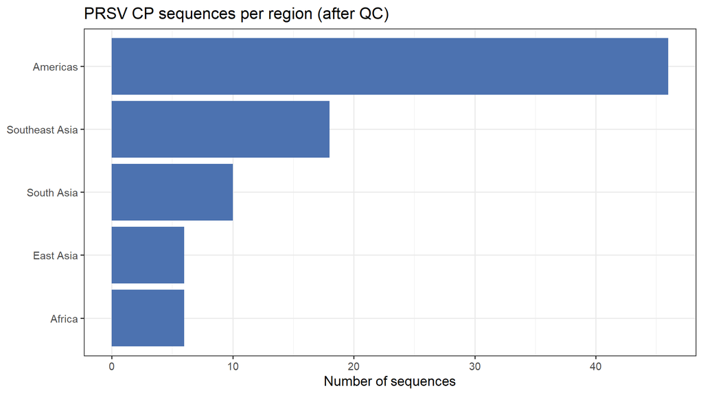

```r
p_counts <- ggplot(count(kept, region), aes(reorder(region, n), n)) +
  geom_col(fill = "#4c72b0") + coord_flip() +
  labs(x = NULL, y = "Number of sequences", title = "PRSV CP sequences per region (after QC)") +
  theme_bw()
save_gg(p_counts, "fig1_sequences_per_region.png", h = 4.5)
```

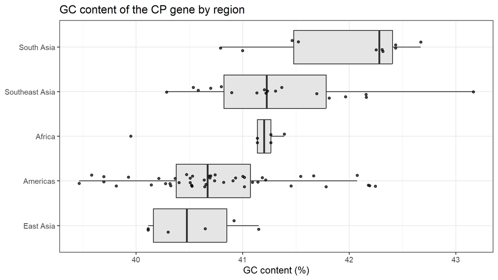

```r
kept <- kept |> mutate(gc = as.numeric(letterFrequency(seqs, "GC", as.prob = TRUE)))

p_gc <- ggplot(kept, aes(reorder(region, gc, FUN = median), 100 * gc)) +
  geom_boxplot(outlier.shape = NA, fill = "grey90") +
  geom_jitter(width = 0.15, size = 1.2, alpha = 0.7) + coord_flip() +
  labs(x = NULL, y = "GC content (%)", title = "GC content of the CP gene by region") +
  theme_bw()
save_gg(p_gc, "fig2_gc_by_region.png", h = 4.5)
```

```r
# Does GC content differ between regions? (non-parametric: small groups)
kw_gc <- kruskal.test(gc ~ factor(region), data = kept)
kw_gc
```

```
##
##  Kruskal-Wallis rank sum test
##
## data:  gc by factor(region)
## Kruskal-Wallis chi-squared = 24.513, df = 4, p-value = 6.302e-05
```

# 6 Hawaiian reference strain

The Hawaiian strains are old GenBank records, so they may not be among the records downloaded above. The **Hawaiian isolate HA** (GenBank X67673, the first complete PRSV genome) is therefore downloaded directly. Its CP gene is cut out by aligning the genome with one of our CP sequences and keeping only the matching region.

```r
ref_file  <- file.path(data_dir, "PRSV_HA_X67673_genome.fasta")
ref_label <- "Hawaii_HA_X67673.1"
if (!file.exists(ref_file)) {
  writeLines(entrez_fetch(db = "nuccore", id = "X67673", rettype = "fasta"), ref_file)
}
genome <- readDNAStringSet(ref_file)

# Align the genome with the longest CP sequence; keep the genome part that
# lines up with it (from the first to the last aligned CP base)
query <- seqs[which.max(width(seqs))]
pair  <- AlignSeqs(OrientNucleotides(c(query, genome), verbose = FALSE),
                   verbose = FALSE, processors = 1)
pm    <- as.matrix(pair)
cols  <- which(!pm[1, ] %in% c("-", "."))
ha_cp <- gsub("[-.]", "", paste(pm[2, min(cols):max(cols)], collapse = ""))

has_ref <- nchar(ha_cp) >= 700 && nchar(ha_cp) <= 1100
cat("Hawaiian HA CP region extracted:", nchar(ha_cp), "bp\n")
```

```
## Hawaiian HA CP region extracted: 948 bp
```

```r
if (!has_ref) warning("Could not extract the CP region from X67673 - Hawaii comparison skipped.")

seqs_aln <- if (has_ref) c(seqs, DNAStringSet(setNames(ha_cp, ref_label))) else seqs

# Lookup tables: label -> region / country (the reference gets its own group)
region_of  <- c(setNames(kept$region, kept$label), setNames("Hawaii (reference)", ref_label))
country_of <- c(setNames(kept$country, kept$label), setNames("USA (Hawaii)", ref_label))
```

# 7 Multiple sequence alignment

DECIPHER first puts all sequences in the same orientation, then aligns them. Columns that are gaps in more than half of the sequences (mostly ragged ends) are removed.

```r
seqs_o <- OrientNucleotides(seqs_aln, verbose = FALSE)
aln    <- AlignSeqs(seqs_o, verbose = FALSE, processors = 1)

aln_mat   <- as.matrix(aln)
keep_cols <- colMeans(aln_mat == "-" | aln_mat == ".") <= 0.5
aln_trim  <- DNAStringSet(apply(aln_mat[, keep_cols], 1, paste0, collapse = ""))
names(aln_trim) <- names(aln)
writeXStringSet(aln_trim, file.path(res_dir, "PRSV_CP_alignment.fasta"))
cat("Alignment length:", ncol(aln_mat), "columns; after trimming:", sum(keep_cols), "\n")
```

```
## Alignment length: 1064 columns; after trimming: 858
```

```r
# Read the alignment into ape's format for distances and trees
dna <- read.dna(file.path(res_dir, "PRSV_CP_alignment.fasta"), format = "fasta")
reg <- unname(region_of[rownames(dna)])
stopifnot("Labels in alignment do not match the sequence table" = !anyNA(reg))
```

# 8 Genetic distances: are strains grouped by region?

Distances are **Kimura 2-parameter (K2P)** distances, the standard model for comparing closely related sequences. Gaps are ignored pair by pair.

```r
Dm <- as.matrix(dist.dna(dna, model = "K80", pairwise.deletion = TRUE))
if (anyNA(Dm) || any(!is.finite(Dm))) stop("Some distances could not be computed.")
Dm[Dm < 0] <- 0  # identical sequences can give -0 from rounding

# H1 uses the regional sequences only (the Hawaiian reference is left out)
use   <- reg != "Hawaii (reference)"
Dm_r  <- Dm[use, use]
reg_r <- reg[use]

# Every pair of sequences: same region or different regions?
idx   <- which(upper.tri(Dm_r), arr.ind = TRUE)
pairs <- tibble(distance = Dm_r[idx],
                type = ifelse(reg_r[idx[, 1]] == reg_r[idx[, 2]], "Same region", "Different regions"))

pairs |> group_by(type) |>
  summarise(n_pairs = n(), mean = mean(distance), median = median(distance),
            max = max(distance)) |>
  knitr::kable(digits = 4, caption = "K2P distances within and between regions")
```

K2P distances within and between regions

| type | n_pairs | mean | median | max |
| --- | --- | --- | --- | --- |
| Different regions | 2392 | 0.1233 | 0.1228 | 0.2252 |
| Same region | 1263 | 0.0778 | 0.0769 | 0.2190 |

```r
# H1: are sequences from different regions more distant? (one-sided Wilcoxon test)
wilcox_reg <- wilcox.test(distance ~ type, data = pairs, alternative = "greater")
wilcox_reg
```

```
##
##  Wilcoxon rank sum test with continuity correction
##
## data:  distance by type
## W = 2581685, p-value < 2.2e-16
## alternative hypothesis: true location shift is greater than 0
```

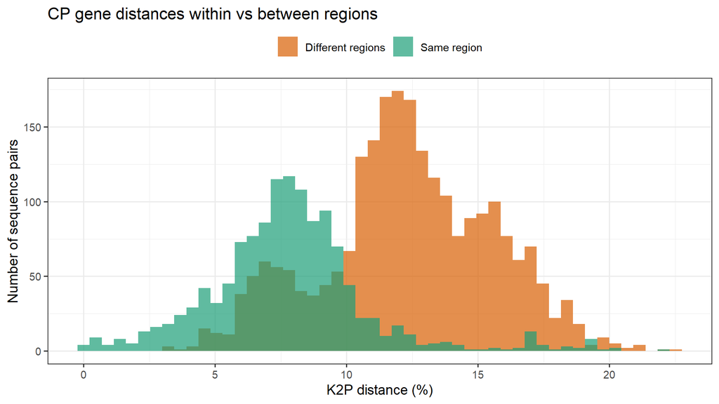

```r
p_hist <- ggplot(pairs, aes(100 * distance, fill = type)) +
  geom_histogram(bins = 50, alpha = 0.7, position = "identity") +
  scale_fill_manual(values = c("Same region" = "#1b9e77", "Different regions" = "#d95f02")) +
  labs(x = "K2P distance (%)", y = "Number of sequence pairs", fill = NULL,
       title = "CP gene distances within vs between regions") +
  theme_bw() + theme(legend.position = "top")
save_gg(p_hist, "fig3_distance_histogram.png", h = 4.5)
```

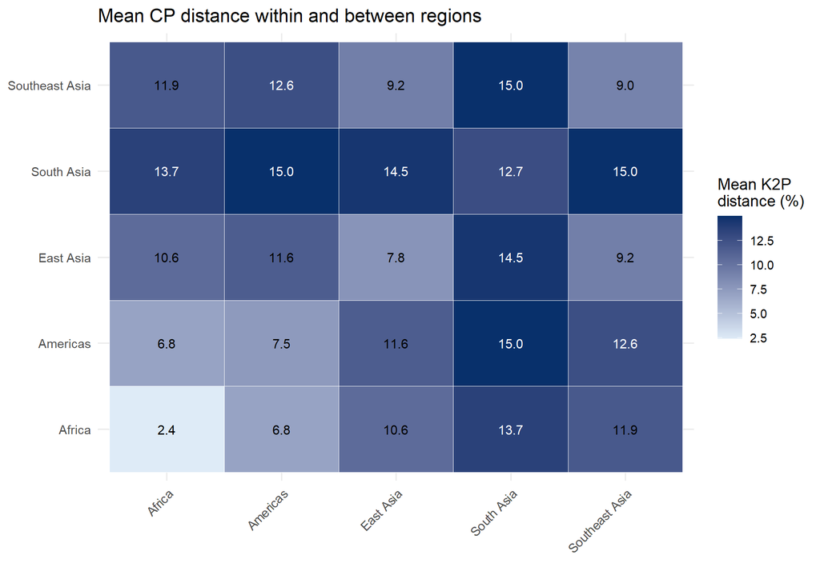

```r
# Mean distance between every pair of regions (diagonal = within a region)
reg_levels <- sort(unique(reg_r))
reg_df <- expand.grid(region1 = reg_levels, region2 = reg_levels, stringsAsFactors = FALSE)
reg_df$mean_distance <- mapply(function(a, b) {
  m <- Dm_r[reg_r == a, reg_r == b, drop = FALSE]
  if (a == b) mean(m[upper.tri(m)]) else mean(m)
}, reg_df$region1, reg_df$region2)
write_csv(reg_df, file.path(res_dir, "mean_distance_between_regions.csv"))

p_heat <- ggplot(reg_df, aes(region1, region2, fill = 100 * mean_distance)) +
  geom_tile(colour = "white") +
  geom_text(aes(label = sprintf("%.1f", 100 * mean_distance),
                colour = mean_distance > median(mean_distance)), size = 3.2,
            show.legend = FALSE) +
  scale_colour_manual(values = c(`TRUE` = "white", `FALSE` = "black")) +
  scale_fill_gradient(low = "#deebf7", high = "#08306b") +
  labs(x = NULL, y = NULL, fill = "Mean K2P\ndistance (%)",
       title = "Mean CP distance within and between regions") +
  theme_minimal() + theme(axis.text.x = element_text(angle = 45, hjust = 1))
save_gg(p_heat, "fig4_region_distance_heatmap.png", h = 5.5)
```

# 9 Phylogenetic tree (neighbour-joining with bootstrap)

```r
# NJ tree on K2P distances; njs() copes with any missing distances
nj_fun <- function(x) {
  d <- dist.dna(x, model = "K80", pairwise.deletion = TRUE)
  if (anyNA(d)) njs(d) else nj(d)
}
tree <- nj_fun(dna)

# Bootstrap: resample alignment columns n_boot times and rebuild the tree
bs <- boot.phylo(tree, dna, nj_fun, B = n_boot, quiet = TRUE)
tree$node.label <- round(100 * bs / n_boot)
tree_rooted <- ladderize(midpoint(tree, node.labels = "support"))
write.tree(tree_rooted, file.path(res_dir, "tree_NJ_bootstrap.nwk"))

tree_levels <- sort(unique(reg))  # includes the Hawaiian reference, if present
region_cols <- setNames(hcl.colors(length(tree_levels), "Dark 3"), tree_levels)

draw_tree <- function() {
  tips <- tree_rooted$tip.label
  plot(tree_rooted, cex = 0.5, no.margin = TRUE, label.offset = 0.001,
       tip.color = region_cols[region_of[tips]],
       font = ifelse(country_of[tips] %in% c("Sri Lanka", "USA (Hawaii)"), 2, 1))  # bold = Sri Lanka / Hawaii
  s <- suppressWarnings(as.numeric(tree_rooted$node.label))
  nodelabels(ifelse(!is.na(s) & s >= 70, s, ""), frame = "none", cex = 0.45, adj = c(1.2, -0.4))
  add.scale.bar(cex = 0.6)
  legend("bottomright", legend = tree_levels, text.col = region_cols, bty = "n", cex = 0.7)
}
png(file.path(fig_dir, "fig5_NJ_tree.png"), width = 8, height = max(8, 0.12 * Ntip(tree_rooted)),
    units = "in", res = 300)
draw_tree(); dev.off()
```

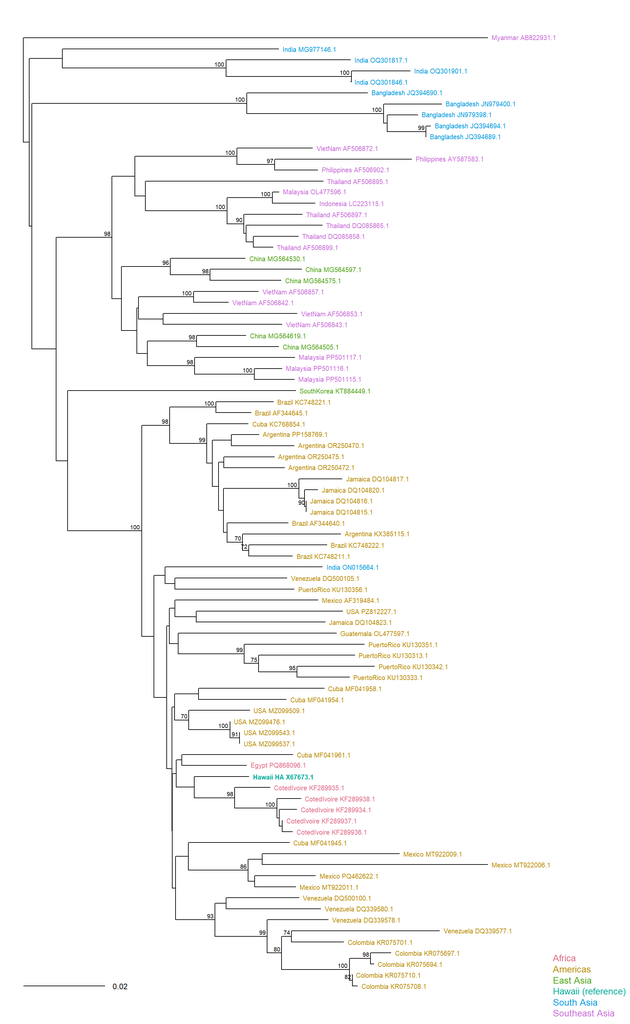

```r
draw_tree()
```

# 10 Similarity to the Hawaiian strain used in resistant papaya

For each non-Hawaiian sequence, the **% identity** to its most similar Hawaiian sequence is calculated (identity = 100 − % of differing bases).

```r
P <- as.matrix(dist.dna(dna, model = "raw", pairwise.deletion = TRUE))
is_hi <- unname(country_of[rownames(P)]) == "USA (Hawaii)"
has_hawaii <- sum(is_hi) > 0
cat("Hawaiian reference sequences:", sum(is_hi), "\n")
```

```
## Hawaiian reference sequences: 1
```

```r
if (!has_hawaii) cat("No Hawaiian sequences passed QC - the next chunk is skipped.\n")
```

```r
ident <- tibble(label    = rownames(P)[!is_hi],
                region   = reg[!is_hi],
                country  = unname(country_of[rownames(P)[!is_hi]]),
                identity = 100 * (1 - apply(P[!is_hi, is_hi, drop = FALSE], 1, min)))
write_csv(ident, file.path(res_dir, "identity_to_hawaii.csv"))

ident |> group_by(region) |>
  summarise(n = n(), mean_identity = mean(identity), min_identity = min(identity)) |>
  arrange(mean_identity) |>
  knitr::kable(digits = 1, caption = "CP identity (%) to the closest Hawaiian strain")
```

CP identity (%) to the closest Hawaiian strain

| region | n | mean_identity | min_identity |
| --- | --- | --- | --- |
| South Asia | 10 | 87.6 | 85.8 |
| Southeast Asia | 18 | 90.0 | 84.9 |
| East Asia | 6 | 91.0 | 90.3 |
| Americas | 46 | 94.3 | 90.3 |
| Africa | 6 | 96.5 | 96.1 |

```r
if (any(ident$country == "Sri Lanka")) {
  knitr::kable(filter(ident, country == "Sri Lanka"), digits = 1,
               caption = "Sri Lankan sequences: identity to the Hawaiian strain")
}

# H2: does identity to the Hawaiian strain differ between regions?
kw_hi <- kruskal.test(identity ~ factor(region), data = ident)
kw_hi
```

```
##
##  Kruskal-Wallis rank sum test
##
## data:  identity by factor(region)
## Kruskal-Wallis chi-squared = 64.13, df = 4, p-value = 3.925e-13
```

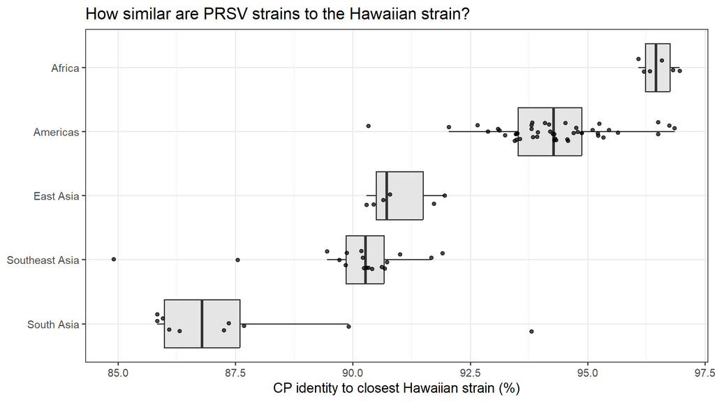

```r
p_hi <- ggplot(ident, aes(reorder(region, identity, FUN = median), identity)) +
  geom_boxplot(outlier.shape = NA, fill = "grey90") +
  geom_jitter(width = 0.15, size = 1.2, alpha = 0.7) + coord_flip() +
  labs(x = NULL, y = "CP identity to closest Hawaiian strain (%)",
       title = "How similar are PRSV strains to the Hawaiian strain?") +
  theme_bw()
save_gg(p_hi, "fig6_identity_to_hawaii.png", h = 4.5)
```

# 11 Summary numbers for the report

```r
same <- pairs$distance[pairs$type == "Same region"]
diff <- pairs$distance[pairs$type == "Different regions"]

key <- c(
  sprintf("GenBank records downloaded: %d; sequences analysed: %d from %d countries in %d regions",
          nrow(info), nrow(kept), n_distinct(kept$country), length(reg_levels)),
  paste("Regions:", paste(sprintf("%s (%d)", count(kept, region)$region, count(kept, region)$n), collapse = ", ")),
  sprintf("Sri Lankan sequences analysed: %d", sum(kept$country == "Sri Lanka")),
  sprintf("Alignment length: %d columns; after trimming: %d", ncol(aln_mat), sum(keep_cols)),
  sprintf("Sequence length: median %d bp (range %d-%d); GC: mean %.1f%%",
          as.integer(median(kept$length)), min(kept$length), max(kept$length), 100 * mean(kept$gc)),
  sprintf("GC by region, Kruskal-Wallis: chi2 = %.2f, df = %d, p = %.3g",
          kw_gc$statistic, as.integer(kw_gc$parameter), kw_gc$p.value),
  sprintf("K2P same region: mean %.2f%%; different regions: mean %.2f%%", 100 * mean(same), 100 * mean(diff)),
  sprintf("Wilcoxon (different > same region): W = %.0f, p = %.3g", wilcox_reg$statistic, wilcox_reg$p.value),
  sprintf("Overall max K2P distance (regional sequences): %.2f%%", 100 * max(Dm_r)),
  sprintf("Hawaiian HA reference (X67673) CP extracted: %s (%d bp)", has_ref, nchar(ha_cp))
)
if (has_hawaii) {
  hi_sum <- ident |> group_by(region) |> summarise(m = mean(identity)) |> arrange(m)
  key <- c(key,
    sprintf("Hawaiian reference sequences: %d", sum(is_hi)),
    paste("Mean identity to Hawaiian strain by region:",
          paste(sprintf("%s %.1f%%", hi_sum$region, hi_sum$m), collapse = ", ")),
    sprintf("Identity to Hawaii, Kruskal-Wallis: chi2 = %.2f, df = %d, p = %.3g",
            kw_hi$statistic, as.integer(kw_hi$parameter), kw_hi$p.value))
}
writeLines(key, file.path(res_dir, "key_numbers.txt"))
cat(key, sep = "\n")
```

```
## GenBank records downloaded: 1000; sequences analysed: 86 from 22 countries in 5 regions
## Regions: Africa (6), Americas (46), East Asia (6), South Asia (10), Southeast Asia (18)
## Sri Lankan sequences analysed: 0
## Alignment length: 1064 columns; after trimming: 858
## Sequence length: median 850 bp (range 757-948); GC: mean 41.0%
## GC by region, Kruskal-Wallis: chi2 = 24.51, df = 4, p = 6.3e-05
## K2P same region: mean 7.78%; different regions: mean 12.33%
## Wilcoxon (different > same region): W = 2581685, p = 2.36e-273
## Overall max K2P distance (regional sequences): 22.52%
## Hawaiian HA reference (X67673) CP extracted: TRUE (948 bp)
## Hawaiian reference sequences: 1
## Mean identity to Hawaiian strain by region: South Asia 87.6%, Southeast Asia 90.0%, East Asia 91.0%, Americas 94.3%, Africa 96.5%
## Identity to Hawaii, Kruskal-Wallis: chi2 = 64.13, df = 4, p = 3.92e-13
```